# Association rules in Scrabble game

## Influance on scrabble game

While playing scrabble we see on the board some leeters that can be connected with our titles with letters. To decide where on the board should we put our letters we ask ourselfs : What letters can I add to ex. letter “p”?

Code below could help us answer this question

```r
rules_scrabble<-apriori(data=scrabble, parameter=list(supp=0.01,conf = 0.05, minlen=4),
                          appearance=list(default="lhs", rhs="p"), control=list(verbose=F))
rules_scrabble_lift<-sort(rules_scrabble, by="lift", decreasing=TRUE)
inspect(head(rules_scrabble_lift))
```

```
##     lhs            rhs support    confidence coverage   lift     count
## [1] {h,i,o}     => {p} 0.01165032 0.3864155  0.03014972 1.798815  677
## [2] {a,h,o}     => {p} 0.01037687 0.3650121  0.02842884 1.699179  603
## [3] {e,i,o,r,s} => {p} 0.01196008 0.3405194  0.03512304 1.585162  695
## [4] {i,o,r,s}   => {p} 0.01822406 0.3252457  0.05603166 1.514061 1059
## [5] {e,i,o,r}   => {p} 0.02078816 0.3173102  0.06551368 1.477121 1208
## [6] {h,o,r}     => {p} 0.01165032 0.3134259  0.03717088 1.459039  677
```

```r
rules_scrabble_count<-sort(rules_scrabble, by="count", decreasing=TRUE)
inspect(head(rules_scrabble_count))
```

```
##     lhs        rhs support    confidence coverage  lift     count
## [1] {e,r,s} => {p} 0.04871795 0.2476382  0.1967303 1.152788 2831
## [2] {e,i,r} => {p} 0.04756496 0.2511129  0.1894166 1.168964 2764
## [3] {e,i,s} => {p} 0.04389950 0.2300478  0.1908277 1.070903 2551
## [4] {e,r,t} => {p} 0.04254001 0.2350704  0.1809671 1.094283 2472
## [5] {a,e,r} => {p} 0.04152469 0.2232812  0.1859749 1.039403 2413
## [6] {e,o,r} => {p} 0.04009637 0.2793765  0.1435209 1.300534 2330
```

```r
rules_scrabble_coverage<-sort(rules_scrabble, by="coverage", decreasing=TRUE)
inspect(head(rules_scrabble_coverage))
```

```
##     lhs        rhs support    confidence coverage  lift      count
## [1] {e,r,s} => {p} 0.04871795 0.2476382  0.1967303 1.1527883 2831
## [2] {e,i,n} => {p} 0.03746343 0.1947227  0.1923937 0.9064598 2177
## [3] {e,i,s} => {p} 0.04389950 0.2300478  0.1908277 1.0709026 2551
## [4] {e,i,r} => {p} 0.04756496 0.2511129  0.1894166 1.1689636 2764
## [5] {a,e,r} => {p} 0.04152469 0.2232812  0.1859749 1.0394033 2413
## [6] {e,i,t} => {p} 0.04001033 0.2166822  0.1846498 1.0086840 2325
```

```
## To reduce overplotting, jitter is added! Use jitter = 0 to prevent jitter.
```

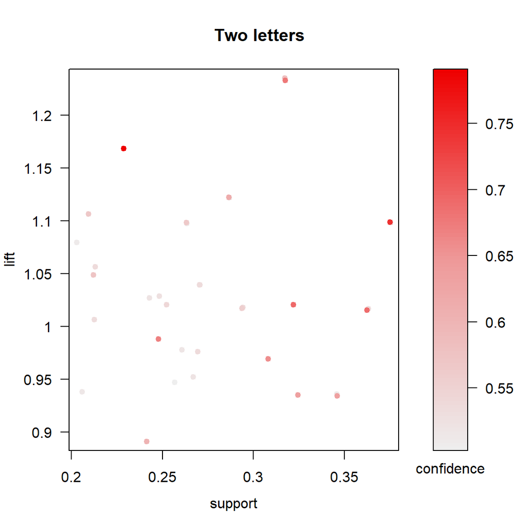

```r
plot(scrabblerules2, measure=c("support","lift"), shading="confidence",main="Two letters")
```

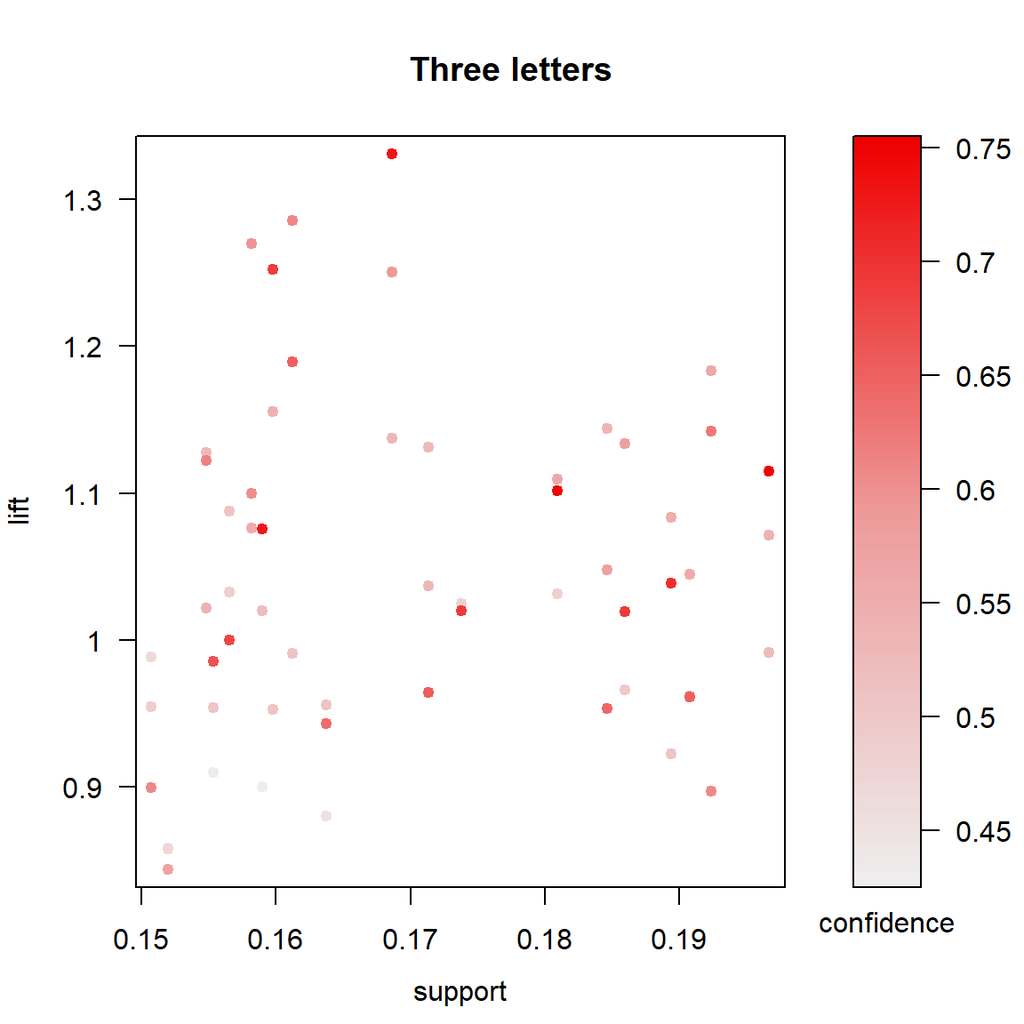

```r
plot(scrabblerules3, measure=c("support","lift"), shading="confidence",main="Three letters")
```

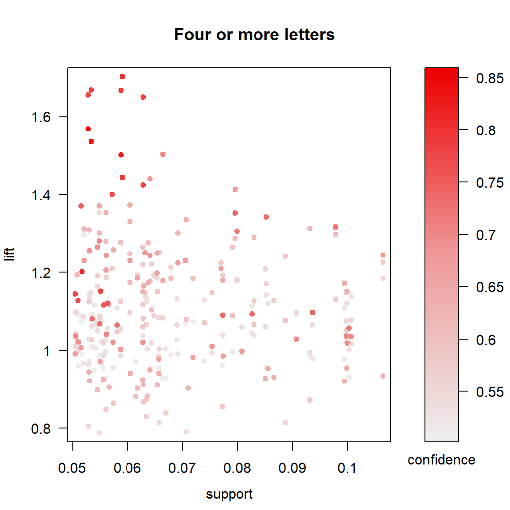

```r
plot(scrabblerules4, measure=c("support","lift"), shading="confidence",main="Four or more letters")
```

[output not shown]

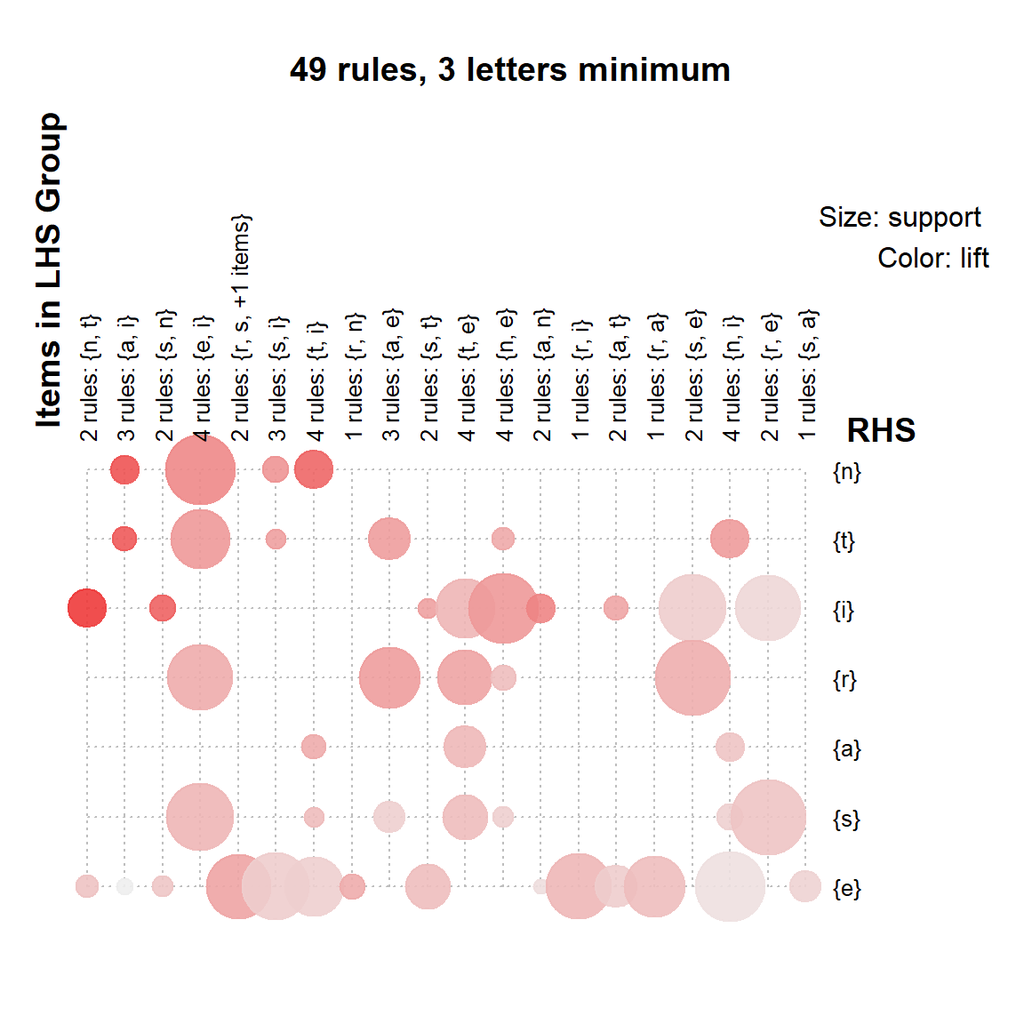

```r
plot(apriori(scrabble, parameter = list(support = 0.15, confidence = 0.5,  minlen = 3)), method="grouped", main= "49 rules, 3 letters minimum")
```

[output not shown]

[output not shown]

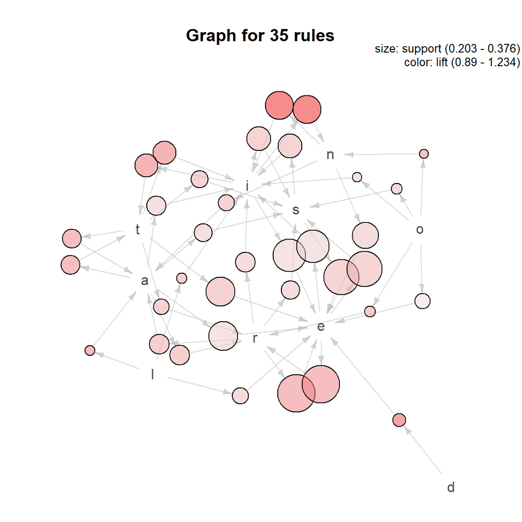

```r
plot(apriori(scrabble, parameter = list(support = 0.2, confidence = 0.5,  minlen = 2)), method="graph", col=rainbow(100))
```

## Conclusion All of the graphs represent some of the associations rules obtained by apriori algorithm. As we can see, the most frequent letter in the dataset is e, followed by: i s a and r. These letters are also main ones in the last graph and exist in most of the most common association rules.

Having this kind of assocation rules for each letter could be very helpful like in this example.

By visualising these rules and plots, we can come up with a more detailed explanation of how to make decisions during game.

I hope this analysis would help us winning games:)

### References

- - https://www.britannica.com/sports/Scrabble
- ** Apriori algorithm. (2021, January 18). Retrieved February 28, 2021, from https://en.wikipedia.org/wiki/Apriori_algorithm
- *** https://www.kdnuggets.com/2016/04/association-rules-apriori-algorithm-tutorial.html
- R code from classes